# Analysis of the NOAA Storm Database and Severe Weather events

Chris Shaw

14 March 2016

## Synopsis

There was around $315bn of property damage and $18bn of crop damage also during that period. Flood was the largest contributor to property damage, while drought being the largest cause of damage to crops. California and Texas suffered the greatest ecomonic impact to property and crops respectively.

## Introduction

Storms and other severe weather events can cause both public health and economic problems for communities and municipalities. Many severe events can result in fatalities, injuries, and property damage, and preventing such outcomes to the extent possible is a key concern.

The government have requested this report to help prepare for severe weather events, including prioritisation of resources for different types of events. The following questions are addressed:

1. Across the United States, which types of events are most harmful with respect to population health?
2. Across the United States, which types of events have the greatest economic consequences?

The analysis is based upon the U.S. National Oceanic and Atmospheric Administration’s (NOAA) storm database. This database tracks characteristics of major storms and weather events in the United States, including when and where they occur, as well as estimates of any fatalities, injuries, and property damage.

## Data Processing

A number of steps are required to prepare the data before analysis which are described below. Some decisions have been made during the processing which impact the results, so a justification is provided.

### Acquiring the data

```r
# Load libraries needed for analysis
library(R.utils)
library(plyr)
library(dplyr)
library(ggplot2)
library(scales)
library(knitr)
library(htmlTable)
knitr::opts_chunk$set(echo = TRUE)
```

The raw data was provided as an internet url. The dataset is rather large, and downloaded for further analysis.

```r
rawdata_url <- "https://d396qusza40orc.cloudfront.net/repdata%2Fdata%2FStormData.csv.bz2"
rawdata_file <- "storm_data.csv.bz2"
rawdata_csv <- "storm_data.csv"

if(!file.exists(rawdata_file)) {
        download.file(url = rawdata_url, destfile = rawdata_file)
        bunzip2(filename = rawdata_file, destname = rawdata_csv)
}
storm_data <- read.csv(rawdata_csv)
```

The raw data contains 902,297 weather observations and 37 variables for each observation. The total number of fatalities recorded in the raw data was 15,145, and the total number of injuries was 140,528.

These totals will be used to cross check the analytic data set to ensure accuracy.

The events in the database start in the year 1950 and end in November 2011. In the earlier years of the database there are generally fewer events recorded, most likely due to a lack of good records. More recent years are more complete.

### Cleaning and transforming the data

The first task is to create a smaller dataset with only those items relevant to the analysis. A new variable called **year** is created to assist with group of events by calender year later on.

```r
events<-storm_data %>% select(EVTYPE, BGN_DATE, FATALITIES, INJURIES, PROPDMG,
                              PROPDMGEXP, CROPDMG, CROPDMGEXP, STATE)
events$BGN_DATE <- as.Date(events$BGN_DATE, "%m/%d/%Y %H:%M:%S")
events$year <- as.numeric(format(events$BGN_DATE, "%Y"))
```

Two transformations have been applied to the data. The first is combine the **DMG** and **DMGEXP** variables for crop and property damage. In the raw data, the first contains a number and the second contains the units of measurement in US dollars (k=thousand, m=million and b=billion). Some observations have other indicators which could not be reliably interpreted, so these are set to zero for this analysis.

The correct scaling factor is applied to these and multiplied to create a new **dmg_k** variable to give a consistent economic damage value in thousand dollar units.

```r
# Convert crop damage into consistent units and multiply
events$CROPDMGEXP<-mapvalues(events$CROPDMGEXP,
                             from = c("",  "?", "0", "2", "B", "k", "K", "m", "M"),
                             to = c(0,0,0,0,1000000, 1, 1, 1000, 1000))
events$cropdmg_k<-events$CROPDMG * as.numeric(as.character(events$CROPDMGEXP))

# Convert property damage into consistent units and multiply
events$PROPDMGEXP<-mapvalues(events$PROPDMGEXP,
                             from = c("M", "m", "K", "B", "", "-", "?", "+", "0", "1", "2",
                                      "3", "4", "5", "6", "7", "8", "h", "H"),
                             to = c(1000, 1000, 1, 1000000, 0,0,0,0,0,0,0,
                                    0,0,0,0,0,0,0,0))
events$propdmg_k<-events$PROPDMG * as.numeric(as.character(events$PROPDMGEXP))
```

The second transformation is to relabel the names of some events. During exploratory analysis it became clear that some types of similar events are labelled differently due to spelling mistakes and multiple categorisations.

For the analysis in this report, a certain number of categories have been relabelled as shown below. There are over 900 different event types, and only a few key ones have been selected that are material for this analysis. For example, all the different types of flooding are categorised as Flood.

```r
events$EVTYPE<-revalue(events$EVTYPE, c("TSTM WIND"="THUNDERSTORM","FLASH FLOOD"="FLOOD",
                                        "FLASH FLOOD/FLOOD"="FLOOD", "FLASH FLOODING"="FLOOD",
                                        "HIGH WINDS"="HIGH WIND", "RIVER FLOOD"="FLOOD",
                                        "THUNDERSTORM WIND"="THUNDERSTORM", "THUNDERSTORM WINDS"="THUNDERSTORM",
                                        "TORNADOES, TSTM WIND, HAIL"="TORNADO", "EXTREME HEAT"="HEAT","WILD/FOREST FIRE"="WILDFIRE",
                                        "DAMAGING FREEZE"="FREEZE", "HEAVY RAIN/SEVERE WEATHER"="HEAVY RAIN",
                                        "HURRICANE OPAL"="HURRICANE", "RIP CURRENTS"="RIP CURRENT", "EXTREME COLD/WIND CHILL"="COLD",
                                        "HURRICANE/TYPHOON"="HURRICANE", "WILD FIRES"="WILDFIRE",
                                        "STORM SURGE/TIDE"="STORM SURGE", "HURRICANE ERIN"="HURRICANE",
                                        "FLOOD/FLASH FLOOD"="FLOOD",
                                        "HEAT WAVE"="HEAT", "River Flooding"="FLOOD",
                                        "EXCESSIVE HEAT"="HEAT", "FROST/FREEZE"="FREEZE",
                                        "COLD/WIND CHILL"="COLD", "EXTREME COLD"="COLD",
                                        "HEAVY SURF/HIGH SURF"="HIGH SURF"))
#detach("package:plyr", unload=TRUE)
```

### Creating an analytic dataset

After cleaning and transforming the data, the last step is to calculate annual percentage contributions of each health and economic effect, grouped by event type and state.

The total injuries, fatalities, property and crop damage is calculated per year across all recorded event types, and then the percentage contribution from each event type can be calculated for that year. A similar calculation can be done by state.

This allows an analysis for each year of which events have the greatest percentage risk of occuring, and also which states bear the brunt of the public health and economic impacts.

```r
# Helper function for avoiding errors when calculating percentages
divide <- function(a,b) ifelse(b==0,0,a/b)

# Group the data by year and one other factor passed in as a variable grp
# The group_by_ function allows for dynamic grouping variables to be specified
group_events <- function(grp) {
                events %>% group_by(year) %>%
                            mutate(total_annual_events = n(),
                                   total_annual_injuries = sum(INJURIES),
                                   total_annual_fatalities = sum(FATALITIES),
                                   total_annual_property_damage = sum(propdmg_k),
                                   total_annual_crop_damage = sum(cropdmg_k)) %>%
                            group_by_(.dots=c("year", sprintf("%s",grp),
                                              "total_annual_events",
                                              "total_annual_injuries",
                                              "total_annual_fatalities",
                                              "total_annual_property_damage",
                                              "total_annual_crop_damage" ))  %>%
                            summarise(number_of_events = n(),
                                   event_injuries = sum(INJURIES),
                                   event_fatalities = sum(FATALITIES),
                                   event_property_damage = sum(propdmg_k),
                                   event_crop_damage = sum(cropdmg_k)) %>%
                             mutate(event_injury_percent = divide(event_injuries,
                                                                  total_annual_injuries),
                                    event_fatality_percent = divide(event_fatalities,
                                                               total_annual_fatalities),
                                    event_property_damage_percent = divide(event_property_damage,total_annual_property_damage),
                                    event_crop_damage_percent = divide(event_crop_damage,total_annual_crop_damage))
}

annual_events <- group_events("EVTYPE")
annual_states <- group_events("STATE")

# Create a summary of the analytic data totals
analytic_summary <- data.frame( c("Number of observations", "Number of Fatalities",
                               "Number of Injuries",
                               "Total Property damage (&dollar;'000)",
                               "Total Crop damage (&dollar;'000)"),
                             c(sum(annual_events$number_of_events),
                               sum(annual_events$event_fatalities),
                               sum(annual_events$event_injuries),
                               sum(annual_events$event_property_damage),
                               sum(annual_events$event_crop_damage)))

analytic_summary <- as.data.frame(sapply(analytic_summary, format, digits=0,
                                         big.mark = ',', scientific=999, trim=TRUE))
options(table_counter=TRUE)
htmlTable(analytic_summary, rnames=FALSE, header=c("",""), align="lr",
          caption = "Summary of full analytic data set", css.table="width:80%;  margin-left:10%;
    margin-right:10%;",col.rgroup = c("none", "#F7F7F7"))
```

| Table 1: Summary of full analytic data set | Table 1: Summary of full analytic data set |
| --- | --- |
| Number of observations | 902,297 |
| Number of Fatalities | 15,145 |
| Number of Injuries | 140,528 |
| Total Property damage ($’000) | 427,318,642 |
| Total Crop damage ($’000) | 49,104,192 |

The data in table 1 agrees with the totals calculated frm the raw data. We can also see the full economic data after the data transformations. Note that this table summarises the whole data set from 1950 to 2011. Later analysis will restrict this period to more recent history.

To help with further analysis, a number of R functions were created to summarise the data into helpful categories.

```r
# Helper functions to summarise data frames which have a text column followed by
# numerical ones
# crunch keeps specified rows in a data.frame and rolls up the others into a single
# row with the label text.
crunch <- function(df,rowstokeep, rolleduptext,rowstosum=-(rowstokeep)) {
        totals=list()
        for (i in 2:ncol(df)) totals[i-1]<- sum(df[rowstosum,i])
        rbind(df[rowstokeep,],setNames(data.frame(rolleduptext, totals), names(df)))
}
# totalcrunch calls crunch twice - first to crunch the data frame and again to add
# a grand total row
totalcrunch <- function(df, rowstokeep, rolleduptext, totaltext="TOTAL"){
        crunch(crunch(df, rowstokeep, rolleduptext), 1:(length(rowstokeep)+1),
                          totaltext, 1:(length(rowstokeep)+1))
}

# sumcolumn groups a dataframe by a column and then sums by that column
sumcolumn <- function(df, grouping_col, sum_col){
        df %>% group_by_(grouping_col) %>%
                summarise_(.dots=setNames(list(sprintf("sum(%s)",sum_col)), sum_col))  %>%
                arrange_(sprintf("desc(%s)",sum_col))
}

summary_table_twocol<- function (df,grp_by, col_1, col_2, caption="",
                                 top=10, other="(OTHER)"){
        lhs <- sumcolumn(df, grp_by,col_1[1])
        rhs <- sumcolumn(df, grp_by,col_2[1])
        top_impacts <- cbind(data.frame(n=c(1:top,"","")),
                                 totalcrunch(lhs, 1:top, other),
                                 totalcrunch(rhs , 1:top, "&nbsp;","&nbsp;")
                                 )
        top_impacts <- sapply(top_impacts, format, digits=0,
                              big.mark = ',', scientific=999, trim=TRUE )

        htmlTable(top_impacts, rnames=FALSE, header=c("","","","",""), align="llrlr",
          cgroup = c("",col_1[2], col_2[2]), caption = caption,
          n.cgroup = c(1,2,2), total = TRUE, css.table="width:80%;  margin-left:10%;
    margin-right:10%;",col.rgroup = c("none", "#F7F7F7"))
}

summary_table_fourcol<- function (df,grp_by, col_1, col_2, col_3, col_4,caption="",
                                  top=10, other="(OTHER)"){
        c1 <- sumcolumn(df, grp_by,col_1[1])
        c2 <- sumcolumn(df, grp_by,col_2[1])
        c3 <- sumcolumn(df, grp_by,col_3[1])
        c4 <- sumcolumn(df, grp_by,col_4[1])
        top_impacts <- cbind(data.frame(n=c(1:top,"","")),
                                 totalcrunch(c1, 1:top, other),
                                 totalcrunch(c2 , 1:top, "&nbsp;","&nbsp;"),
                                 totalcrunch(c3 , 1:top, "&nbsp;","&nbsp;"),
                                 totalcrunch(c4 , 1:top, "&nbsp;","&nbsp;")
                                 )

        top_impacts <- sapply(top_impacts, format, digits=0,
                              big.mark = ',', scientific=999, trim=TRUE)

        htmlTable(top_impacts, rnames=FALSE, header=c("","","","","","","","",""), align="llrlrlrlr",
          cgroup = c("",col_1[2], col_2[2], col_3[2], col_4[2]), caption = caption,
          n.cgroup = c(1,2,2,2,2), total = TRUE, css.table="width:80%;  margin-left:10%;
    margin-right:10%;",col.rgroup = c("none", "#F7F7F7"))
}
```

## Results

There is one final assumption made which is the period over which to analyse the data. The early data is incomplete so including it will distort the numbers disproportionally (e.g. Tornado data has been collected as far back as 1950, but it’s hard to compare the effects to other things in that year).

```r
start_year <- 2001
analysis_annual_events <- annual_events  %>% filter(year>start_year)
analysis_annual_states <- annual_states  %>% filter(year>start_year)
```

### Weather events with the greatest economic and health impacts

Table 2 shows the ten most severe weather events which caused the highest number of fatalities and injuries during the period.

```r
summary_table_twocol(analysis_annual_events, "EVTYPE", c("event_fatalities","Fatalities"), c("event_injuries","Injuries"), sprintf("Top 10 Public Health impacts %d - 2011", start_year))
```

| Table 2: Top 10 Public Health impacts 2001 - 2011 | Table 2: Top 10 Public Health impacts 2001 - 2011 | Table 2: Top 10 Public Health impacts 2001 - 2011 Fatalities | Table 2: Top 10 Public Health impacts 2001 - 2011 Fatalities | Table 2: Top 10 Public Health impacts 2001 - 2011 | Table 2: Top 10 Public Health impacts 2001 - 2011 Injuries | Table 2: Top 10 Public Health impacts 2001 - 2011 Injuries |
| --- | --- | --- | --- | --- | --- | --- |
| 1 |  | TORNADO | 1,112 |  | TORNADO | 13,588 |
| 2 |  | HEAT | 920 |  | HEAT | 4,019 |
| 3 |  | FLOOD | 786 |  | THUNDERSTORM | 2,546 |
| 4 |  | RIP CURRENT | 384 |  | LIGHTNING | 2,250 |
| 5 |  | LIGHTNING | 370 |  | HURRICANE | 1,291 |
| 6 |  | COLD | 233 |  | WILDFIRE | 1,051 |
| 7 |  | THUNDERSTORM | 207 |  | FLOOD | 818 |
| 8 |  | AVALANCHE | 145 |  | HIGH WIND | 486 |
| 9 |  | HIGH SURF | 118 |  | HAIL | 456 |
| 10 |  | HIGH WIND | 97 |  | WINTER WEATHER | 343 |
|  |  | (OTHER) | 676 |  |  | 2,761 |
|  |  | TOTAL | 5,048 |  |  | 29,609 |

Clearly tornadoes and heat are the number one and two main impacts. Thereafter events have different effects, for example thunderstorms are further down the list of fatalities, although responsible for the third largest number of injuries.

The next area to consider is economic damage of severe weather, captured in terms of property damage and crop damage.

```r
summary_table_twocol(analysis_annual_events, "EVTYPE", c("event_property_damage","Property Damage (&dollar;’000)"), c("event_crop_damage","Crop Damage (&dollar;’000)"), sprintf("Top 10 Economic impacts %d - 2011", start_year))
```

| Table 3: Top 10 Economic impacts 2001 - 2011 | Table 3: Top 10 Economic impacts 2001 - 2011 | Table 3: Top 10 Economic impacts 2001 - 2011 Property Damage ($’000) | Table 3: Top 10 Economic impacts 2001 - 2011 Property Damage ($’000) | Table 3: Top 10 Economic impacts 2001 - 2011 | Table 3: Top 10 Economic impacts 2001 - 2011 Crop Damage ($’000) | Table 3: Top 10 Economic impacts 2001 - 2011 Crop Damage ($’000) |
| --- | --- | --- | --- | --- | --- | --- |
| 1 |  | FLOOD | 144,097,051 |  | DROUGHT | 5,423,625 |
| 2 |  | HURRICANE | 72,342,695 |  | FLOOD | 4,404,421 |
| 3 |  | STORM SURGE | 47,809,503 |  | HURRICANE | 3,056,383 |
| 4 |  | TORNADO | 18,406,923 |  | HAIL | 1,393,288 |
| 5 |  | HAIL | 9,174,278 |  | FREEZE | 1,094,086 |
| 6 |  | THUNDERSTORM | 4,976,962 |  | THUNDERSTORM | 577,897 |
| 7 |  | WILDFIRE | 4,959,547 |  | HIGH WIND | 494,272 |
| 8 |  | HIGH WIND | 4,833,336 |  | HEAT | 492,579 |
| 9 |  | TROPICAL STORM | 2,008,361 |  | TROPICAL STORM | 410,061 |
| 10 |  | ICE STORM | 1,964,718 |  | HEAVY RAIN | 381,045 |
|  |  | (OTHER) | 4,575,873 |  |  | 722,594 |
|  |  | TOTAL | 315,149,246 |  |  | 18,450,250 |

Here there are differences between the two indicators. Flood is responsible for nearly half of the property damage whereas drought tops the list for crop damage. It is perhaps unsurprising that drought does not feature at all in the top ten causes of property damage.

### Distribution of effects across the United States

There are regional differences in the effect of weather across the United States. The states who reported the ten highest indicators across fatalities, injuries, property damage and crop damage are captured in the following table.

```r
summary_table_fourcol(analysis_annual_states, "STATE", c("event_fatalities","Fatalities"), c("event_injuries","Injuries"), c("event_property_damage","Property Damage (&dollar;’000)"), c("event_crop_damage","Crop Damage (&dollar;’000)"), sprintf("Top 10 impacted states %d - 2011", start_year), other="other states")
```

| Table 4: Top 10 impacted states 2001 - 2011 | Table 4: Top 10 impacted states 2001 - 2011 | Table 4: Top 10 impacted states 2001 - 2011 Fatalities | Table 4: Top 10 impacted states 2001 - 2011 Fatalities | Table 4: Top 10 impacted states 2001 - 2011 | Table 4: Top 10 impacted states 2001 - 2011 Injuries | Table 4: Top 10 impacted states 2001 - 2011 Injuries | Table 4: Top 10 impacted states 2001 - 2011 | Table 4: Top 10 impacted states 2001 - 2011 Property Damage ($’000) | Table 4: Top 10 impacted states 2001 - 2011 Property Damage ($’000) | Table 4: Top 10 impacted states 2001 - 2011 | Table 4: Top 10 impacted states 2001 - 2011 Crop Damage ($’000) | Table 4: Top 10 impacted states 2001 - 2011 Crop Damage ($’000) |
| --- | --- | --- | --- | --- | --- | --- | --- | --- | --- | --- | --- | --- |
| 1 |  | MO | 356 |  | MO | 4,507 |  | CA | 120,405,066 |  | TX | 3,815,721 |
| 2 |  | TX | 349 |  | AL | 2,815 |  | LA | 55,893,867 |  | IA | 2,373,061 |
| 3 |  | FL | 339 |  | TN | 1,804 |  | FL | 32,324,672 |  | FL | 1,875,484 |
| 4 |  | AL | 334 |  | TX | 1,732 |  | MS | 27,724,828 |  | MS | 1,606,258 |
| 5 |  | IL | 300 |  | FL | 1,667 |  | TX | 12,640,716 |  | CA | 1,331,983 |
| 6 |  | CA | 296 |  | CA | 1,496 |  | AL | 9,640,224 |  | NE | 917,765 |
| 7 |  | TN | 271 |  | OK | 1,483 |  | TN | 5,581,115 |  | IN | 864,633 |
| 8 |  | PA | 230 |  | GA | 864 |  | MO | 4,347,497 |  | MO | 713,182 |
| 9 |  | NY | 154 |  | NC | 822 |  | OH | 4,182,533 |  | WI | 680,509 |
| 10 |  | NC | 153 |  | MS | 770 |  | AZ | 3,429,562 |  | LA | 572,331 |
|  |  | other states | 2,266 |  |  | 11,649 |  |  | 38,979,167 |  |  | 3,699,324 |
|  |  | TOTAL | 5,048 |  |  | 29,609 |  |  | 315,149,246 |  |  | 18,450,250 |

The states of Missouri, California, Texas and Florida feature in the top ten across all four categories. North Carolina records high levels of public health impacts, but not econmically, whereas Louisiana has the opposite.

Further analysis of the Louisiana data shows that the hurricane of 2005 accounted for almost all this total over the period. However, there are no fatalities or injuries recorded for this event which is not correct. The raw data should be re-examined to ensure accuracy.

### Events carrying the largest annual risk

Events that are more than 1% of the annual total are then filtered for further analysis.

```r
lowest_percent=0.01

event_summary <-  analysis_annual_events %>% group_by(EVTYPE) %>%
                 summarise(number_of_events = sum(number_of_events),
                           event_injuries = sum(event_injuries),
                           event_fatalities = sum(event_fatalities),
                           event_property_damage = sum(event_property_damage),
                           event_crop_damage = sum(event_crop_damage),
                           m_fatality_percent = mean(event_fatality_percent),
                           m_injury_percent = mean(event_injury_percent),
                           m_property_percent = mean(event_property_damage_percent),
                           m_crop_percent = mean(event_crop_damage_percent))
```

The following plot shows which events contribute more than 1% of injuries or fatalities on average.

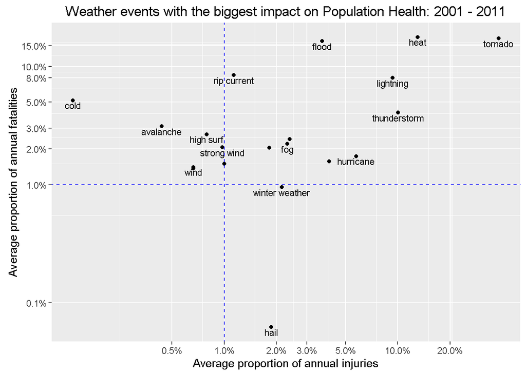

```r
par(mar=c(2,2,4,1))
ggplot(subset(event_summary, (m_fatality_percent >lowest_percent | m_injury_percent >lowest_percent)),
                aes(m_injury_percent, m_fatality_percent), height=800, width=800) +
                geom_point() +
                scale_y_continuous(labels=percent, breaks = c(0.001,0.01,0.02,0.03, 0.05,0.08, 0.1,0.15, 0.2, 0.4,0.6)) +
                scale_x_continuous(labels=percent, breaks = c(0.005,0.01,0.02,0.03, 0.05, 0.1, 0.2, 0.4,0.6)) +
                coord_trans(x="log10", y="log10") +
                geom_text(aes(label=tolower(EVTYPE)), hjust=0.5, vjust=1.2,
                          check_overlap = T, size=3) +
                ylab("Average proportion of annual fatalities") +
                xlab("Average proportion of annual injuries") +
                geom_segment(y=lowest_percent,yend=lowest_percent,x=0.0001,xend=1, colour="blue", linetype="dashed") +
                geom_segment(y=0.0001,yend=1,x=lowest_percent,xend=lowest_percent, colour="blue", linetype="dashed") +
                ggtitle(sprintf("Weather events with the biggest impact on Population Health: %d - 2011", start_year))
```

There are a number of events that produce more than 1% on both measures. Hail has a significant contribution to injury but hardly any deaths. Similarly, the Cold causes a high proportion of annual fatality, but not much in the way of injury.

The final plot below highlights events that contribute more than 1% of economic damage to property and crops.

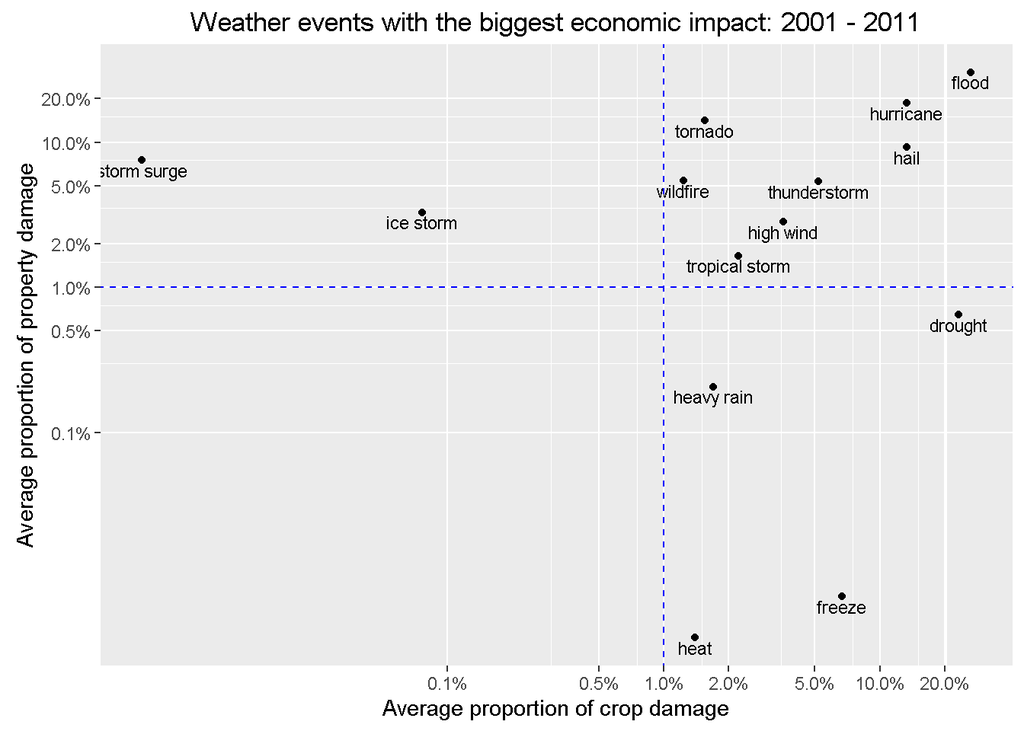

```r
ggplot(subset(event_summary, m_crop_percent >lowest_percent | m_property_percent >lowest_percent),
                aes(m_crop_percent, m_property_percent), height=800, width=800) +
                geom_point() +
                scale_y_continuous(labels=percent, breaks = c(0.001, 0.005,0.01,0.02, 0.05, 0.1, 0.2, 0.4,0.6)) +
                scale_x_continuous(labels=percent, breaks =  c(0.001,0.005, 0.01,0.02, 0.05, 0.1, 0.2, 0.4,0.6)) +
                coord_trans(x="log10", y="log10") +
                geom_text(aes(label=tolower(EVTYPE)), hjust=0.5, vjust=1.2,
                          check_overlap = F, size=3) +
                ylab("Average proportion of property damage") +
                xlab("Average proportion of crop damage") +
                geom_segment(y=lowest_percent,yend=lowest_percent,x=0.0000001,xend=1, colour="blue", linetype="dashed") +
                geom_segment(y=0.0000001,yend=1,x=lowest_percent,xend=lowest_percent, colour="blue", linetype="dashed") +
                ggtitle(sprintf("Weather events with the biggest economic impact: %d - 2011", start_year))
```

Again, there are a number of events which contribute signicantly to both property and crop damage each year.

There are also events which effect one economic indicator more than the other. For example, heat is a significant risk for crops, but hardly causes any property damage.